# San Francisco Crime: Peaks at noon and in late afternoon

Ingo Nader

7 Dec 2015

## Introduction

This document was written to analyze the variation in crimes (i.e., different crime categories) in San Francisco during the summer of 2014 (1 June - 31 August 2014). It was created using `R 3.1.3`, RStudio 0.98.1102 and the `knitr` package. (For reasons why I chose this setup over Juypter, please see [here](http://opiateforthemass.es/articles/why-i-dont-like-jupyter-fka-ipython-notebook/)).

## Data Preparation

```r
library(readr)       ## read_csv()
library(ggplot2)     ## for plotting
library(scales)      ## date scales()
library(grid)        ## unit()
library(lubridate)   ## for date conversions
library(plyr)        ## for creating data summaries

dat_sf <- read.csv(file = "sanfrancisco_incidents_summer_2014.csv")
names(dat_sf) <- tolower(names(dat_sf))
```

Next, we add some additional indicator variables (hour of the day, minute, number of minutes since midnight, as well as the half-hour interval since midnight), and we create a summary for each crime category and each hour of the day:

```r
## add indicators:
dat_sf <- mutate(dat_sf,
    timets = hm(time),              ## time stamp
    hr = hour(hm(time)),            ## hour of the day
    mn = minute(hm(time)),          ## minute
    mncont = hr * 60 + mn,          ## minute of the day (continuous)
    mncont30 = floor(mncont / 30)   ## 30-minute interval of the day
)

## make full grid of all times and categories:
dat_sf_grid <- expand.grid(hr = 0:23, category = levels(dat_sf$category))

## number of crimes per category per hour:
dat_sf_summary <- ddply(dat_sf, c("hr", "category"), summarize,
    cat_sum = length(category))

## add position for plotting additional labels:
dat_sf_summary <- ddply(dat_sf_summary, "hr", transform,
    pos_sum = cumsum(cat_sum) - 0.5 * cat_sum)

## but remove all but 18 (to plot only once), and remove low frequency categories:
dat_sf_summary$pos_sum[dat_sf_summary$hr != 18] <- NA
dat_sf_summary$pos_sum[dat_sf_summary$cat_sum < 50] <- NA

## join summary table to full grid for plotting:
dat_sf_summary <- join(dat_sf_grid, dat_sf_summary, by = c("hr", "category"), type="left")

## replace NA's with 0:
dat_sf_summary$cat_sum[is.na(dat_sf_summary$cat_sum)] <- 0
```

## How do incidents vary by time of day?

In order to inspect how incidents in San Francisco vary by the time of day, we use the summary table to create an area plot visualization. For each hour of the day, the number of occurences for each category are stacked on top of each other, and color coded. Since there are many categories, the colors are not easily distinguishable, so I have added labels within the plot for the most common categories.

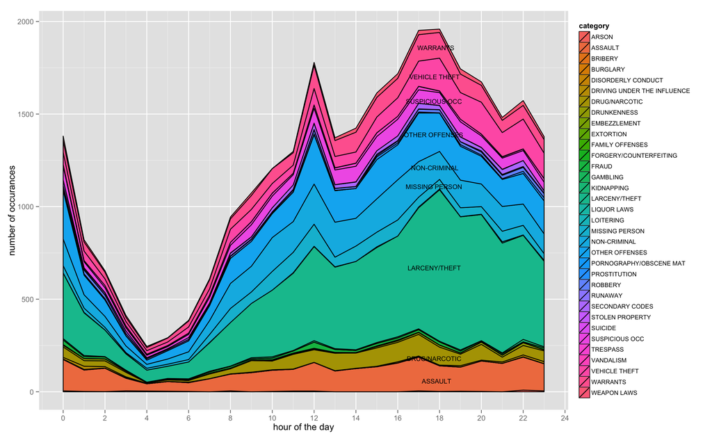

```r
## area plot of absolute values:
ggplot(dat_sf_summary, aes(x=hr, y=cat_sum)) +
    geom_area(aes(fill=category), color="black", position="stack") +
    geom_text(aes(x=hr, y=pos_sum, label=category), size=3, hjust=.6, vjust=1) +
    theme(
        legend.text = element_text(size = 8),#, colour = "red", angle = 0)
        legend.key.size = unit(.5, "cm")
    ) +
    scale_x_continuous(breaks=seq(from=0, to=24, by=2)) +
    xlab("hour of the day") +
    ylab("number of occurances")
```

Some interesting patterns can be seen from the plot:

- The total number of crimes is lowest at about 4 am.
- The total number of crimes has a first peak at noon, then drops slightly, and has another peak during the late afternoon.
- The biggest crime category is `LARCENY/THEFT`, which contributes to both of the peaks (probably more to the afternoon peak).
- The next biggest crime category, after `NON-CRIMINAL` and `OTHER OFFENSES`, is `ASSAULT`, which also contributes to both peaks.

However, the fact that this category is the next biggest is not clearly visible in this plot. In order to make it more clearly visible how each crime category varies by the hour of the day, we create a plot with a panel for each individual category. The categories are sorted by the total number of crimes in that category, but the color coding has been kept unchanged to the plot above. Note that the axes are allowed to vary freely for each plot. This makes it easier to see the patterns in each crime category, but, on the other hand, makes comparisons of number of occurances across different crime categories less easy.